# Homework 6

Jacob Harrell

4/11/2021

**QUESTION 1**

Load data and place within a, unmarkedFramePCount object.

```r
#setwd(choose.dir('HW6'))
library(unmarked)
y <- read.csv('count.csv')

count_mat <- as.matrix(y)

obs_c <- read.csv('obs_covs.csv')
det_covs <- list(
  j = data.frame(obs_c[,c('j1', 'j2', 'j3')])
)
site_covs <- read.csv('site_covs.csv')
site_covs$x2 <- factor(site_covs$x2)

count_data <- unmarkedFramePCount(y = count_mat,
                                  obsCovs = det_covs,
                                  siteCovs = site_covs)
```

**QUESTION 2**

With the data placed within an unmarkedFramPCount object, we can now fit the data into an N-mixture model under the assumption that the conditional detection probability is a function of the provided detection covariate, and that the expected abundance is an additive function of variable x1 and x2.

```r
fit <- pcount(formula = ~ j ~ x1 + x2,
              data = count_data,
              K = 100)
summary(fit)
```

```
##
## Call:
## pcount(formula = ~j ~ x1 + x2, data = count_data, K = 100)
##
## Abundance (log-scale):
##             Estimate     SE     z  P(>|z|)
## (Intercept)    0.915 0.1106  8.27 1.30e-16
## x1             0.370 0.0401  9.21 3.14e-20
## x2b           -0.161 0.1382 -1.16 2.45e-01
## x2c           -0.189 0.1522 -1.24 2.14e-01
## x2d            1.335 0.1195 11.17 5.63e-29
##
## Detection (logit-scale):
##             Estimate     SE     z  P(>|z|)
## (Intercept)    1.259 0.0925  13.6 4.01e-42
## j             -0.841 0.0639 -13.2 1.57e-39
##
## AIC: 1736.028
## Number of sites: 200
## optim convergence code: 0
## optim iterations: 46
## Bootstrap iterations: 0
```

**QUESTION 3**

Now, to interpret the effect x1 would have on the expected count at each site.

```r
betas <- coef(fit)
betas
```

```
##   lam(Int)    lam(x1)   lam(x2b)   lam(x2c)   lam(x2d)     p(Int)       p(j)
##  0.9151447  0.3696188 -0.1606306 -0.1891303  1.3351914  1.2585992 -0.8410807
```

```r
p_sub <- plogis(betas[6] +betas[2])
p_non <- plogis(betas[6])
log((p_sub/(1-p_sub))/(p_non/(1-p_non)))
```

```
##    p(Int)
## 0.3696188
```

**QUESTION 4**

Predict and plot the effect of the supplied detection covariate over the range of the covariate.

```r
new_det <- data.frame(
  j = c(det_covs[['j']]$j1)
)
prd_det <- predict(object = fit,
                   newdata = new_det,
                   type = 'det')
summary(prd_det)
```

```
##    Predicted            SE              lower            upper
##  Min.   :0.1996   Min.   :0.00756   Min.   :0.1526   Min.   :0.2566
##  1st Qu.:0.6398   1st Qu.:0.01430   1st Qu.:0.6050   1st Qu.:0.6731
##  Median :0.7803   Median :0.01593   Median :0.7475   Median :0.8099
##  Mean   :0.7384   Mean   :0.01632   Mean   :0.7049   Mean   :0.7690
##  3rd Qu.:0.8724   3rd Qu.:0.01742   3rd Qu.:0.8417   3rd Qu.:0.8979
##  Max.   :0.9648   Max.   :0.02732   Max.   :0.9466   Max.   :0.9770
```

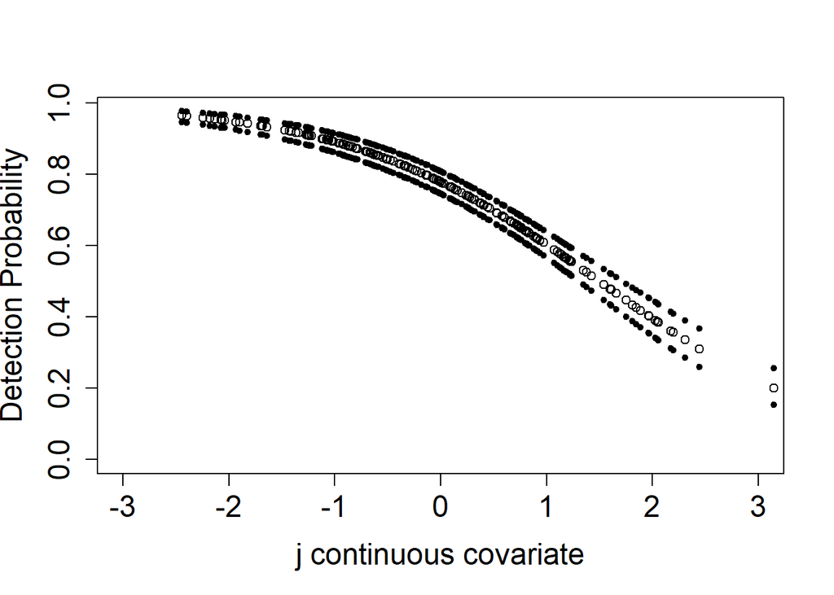

```r
plot(x = det_covs[['j']]$j1,
     y = prd_det[, 'Predicted'], type = 'p',
     xlim = c(-3, 3),
     ylim = c(0, max(prd_det[,'upper'])),
     ylab = 'Detection Probability',
     xlab = 'j continuous covariate',
     cex.axis = 1.5,
     cex.lab = 1.5,
     lwd = 1
     )
points(x = det_covs[['j']]$j1, y = prd_det[, c('lower')], pch = 20, lwd = 1)
points(x = det_covs[['j']]$j1, y = prd_det[, c('upper')], pch = 20, lwd = 1)
```

**QUESTION 5**

Using contrasts, compare the expected abundance between all pairwise levels of variable x2.

```r
x<- matrix(
  c(0, 0, 1, -1, 0,
    0, 0, 1, 0, -1,
    0, 0, 0, 1, -1),
  nrow = 3,
  byrow = T
)
lin_com <- linearComb(obj = fit,
                      coefficients = x,
                      type = 'state')

wald_test <- coef(lin_com)/SE(lin_com)
wald_test
```

```
## [1]   0.2140043 -15.9929898 -13.3713082
```

```r
2 * pnorm(-1 * abs(wald_test))
```

```
## [1] 8.305437e-01 1.430000e-57 8.896230e-41
```

We would fail to reject the null hypothesis that there is no change in expected abundance between x2b and x2c. We would reject the null hypothesis when comparing x2b with x2d and x2c with x2d.